# Dendrometria

UNIDADE 1 - CONTEXTUALIZAÇÃO

Prof. Dr. Gabriel Agostini Orso

gabriel.orso@ufsm.br

Universidade Federal de Santa Maria

3 de agosto de 2026

## Conteúdo

- **UNIDADE 1 - CONTEXTUALIZAÇÃO**
  - 1.1 - Contextualização
  - 1.2 - Símbolos Florestais

# Contextualização

## Importância

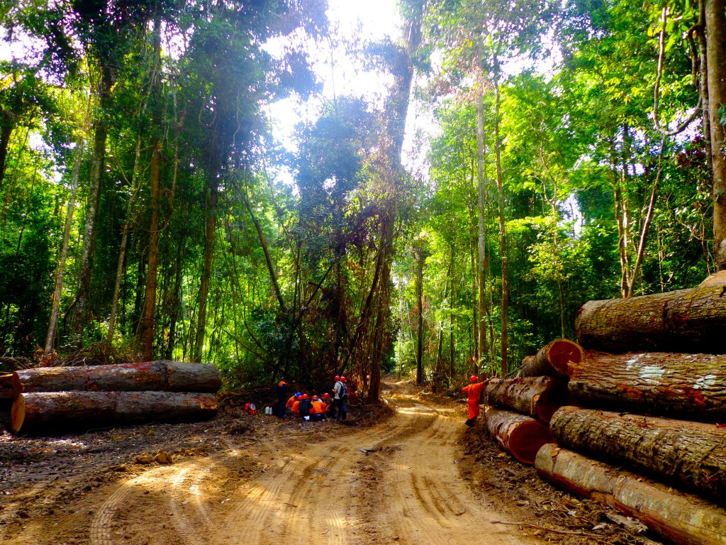

Exploração de florestas naturais

## Importância

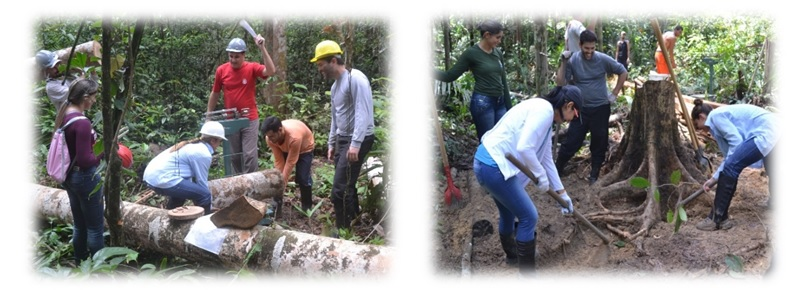

Determinação de Biomassa

## Importância

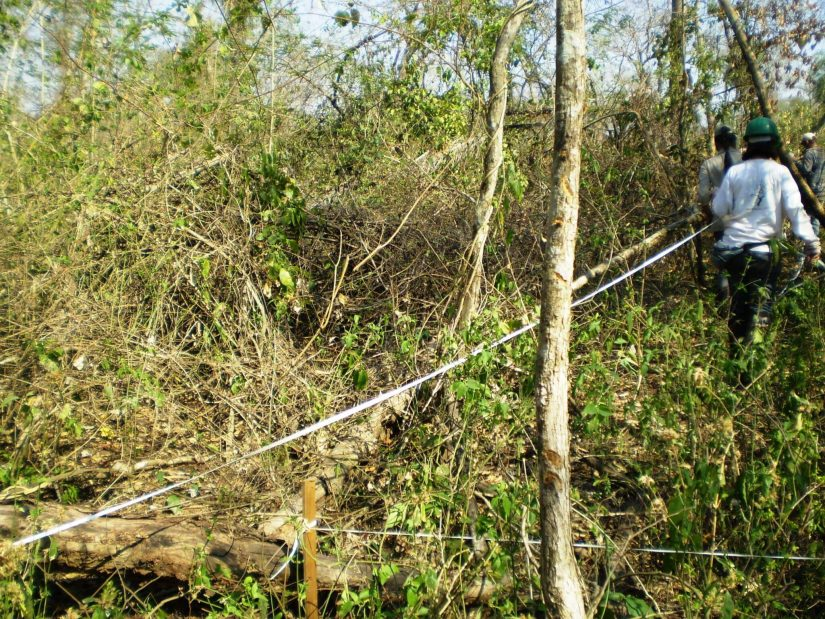

Inventários de supressão de vegetação nativa

## Importância

[interactive chart not shown]

Predição e Prognose do crescimento e produção florestal

## Importância

[interactive chart not shown]

Pesquisa e produção acadêmica em povoamentos ou ecossistemas naturais.

## Importância

O que há em comum?

Todos os exemplos envolvem algum tipo de medição das árvores!

Essas medidas são utilizadas praticamente todas as áreas de atuação profissional.

# Definições

## Definições

Dendrometria é a ciência de mensuração de árvores. A partir dessas medidas, diversas decisões são tomadas.

- Medição de árvores e dos povoamentos florestais, para avaliar as variáveis dendrométricas, bem como estudar seu crescimento.
- Representa a combinação de todos os métodos estatísticos de registro e descrição dos processos da floresta.
- Envolve a avaliação de leis naturais e métodos estatísticos importantes para a floresta.

Finger (2006)

## Definições

O termo dendrometria é de origem grega, e significa medida da árvore (*Dendro* = árvore; *metria* = medida). Desta forma, a dendrometria é a área interligada à ciência florestal que determina com precisão ou estima através de variáveis dendrométricas parâmetros de interesse.

É o estudo, a investigação e o desenvolvimento de métodos para:

1. Determinação das dimensões de árvores em pé, submersas ou ar livre e de seus produtos;
2. Determinação dos volumes de árvores individuais e de florestas e seus produtos;
3. Determinação ou predição de relações de crescimento e incremento de árvores e florestas.

## Definições

### Tipos de medidas

Sobre medição de árvores, existem três tipos de medições:

- Medidas diretas: medidas realizadas diretamente na árvore, como por exemplo, DAP, comprimento de tora, espessura de casca, número de anéis de crescimento, medida de altura da árvore em pé com regra graduada.
- Medidas indiretas: medidas fora do alcance direto do homem, realizada com auxílio de métodos óticos, como exemplo, medição de altura da árvore em pé com aparelhos (que não sejam a regra graduada), área basal, diâmetro em diferentes alturas com auxílio do relascópio.
- Estimativas: são baseadas em métodos estatísticos, onde estimam-se variáveis a partir de outras.

## Definições

### Tipos de medidas

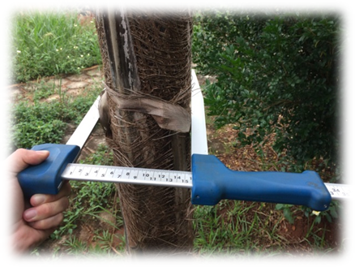

Medição Direta

## Definições

### Tipos de medidas

[figure not shown]

Medição Indireta

## Definições

### Tipos de medidas

[interactive chart not shown]

Estimativas

## Definições

### Precisão e Acurácia

Precisão e Acurácia

## Definições

### Precisão e Acurácia

Precisão e Acurácia

## Definições

### Precisão e Acurácia

Precisão e Acurácia

- Acurácia: indica o quão próximo um resultado está do valor real (exatidão).
- Precisão: mede a consistência, repetibilidade, o quão próximos os valores estão entre si.

# Simbologia

## Simbologia

A Dendrometria transforma indivíduos arbóreos em números. Tudo na árvore é um número que pode ser utilizado para tomar decisões.

Da árvore pode-se medir o diâmetro, a altura, seu peso, seu volume, diâmetro de copa, altura do fuste *etc.*.

Cada variável possui um símbolo matemático associado.

## Simbologia

Ao longo da disciplina, buscaremos seguir os seguintes símbolos:

| Variável | Símbolo | Unidade | Casas decimais |
| --- | --- | --- | --- |
| Diâmetro a 1,3m acima do solo | $d$ ou $DAP$ | metro ou centímetro | 1 |
| Altura | $h$ | metros | 1 |
| Volume da árvore | $v$ | metros cúbicos | 4 |
| Volume por unidade de área | $V$ | metros cúbicos por área | 1 |
| Área transversal por árvore | $g$ | metros quadrados | 4 |
| Área basal | $G$ | metros quadrados por área | 1 |
| Fatores de forma | $f$, $f_{1,3}$, $f_{0,1}$ | - | 4 |

## Simbologia

**Cuidado**

A simbologia por vezes não possui padronização.

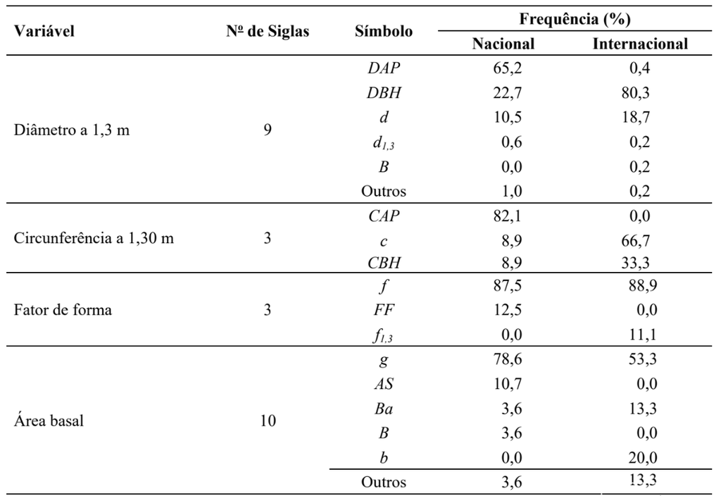

[Fonte](https://drive.google.com/file/d/1nrnSQ1zaC-2HLeTbEDtqwdmMVZ1_SgRT/view)

## Simbologia

A Mensuração Florestal buscou conciliar diferentes simbologias, e propôs uma padronização para uso no Brasil.

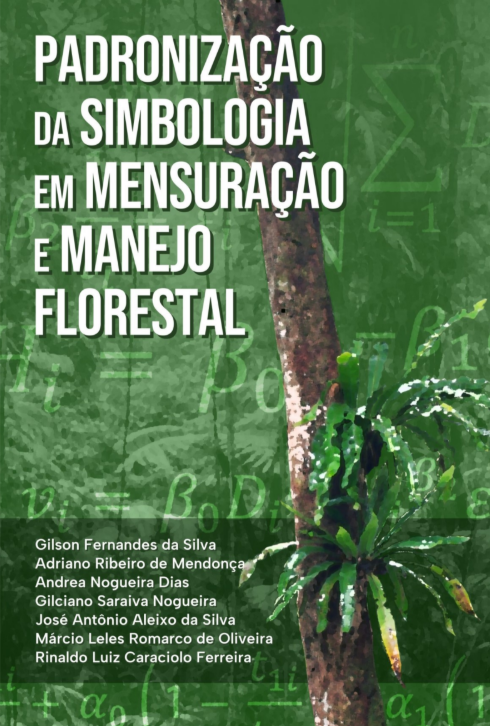

[Silva *et al.* (2022)](https://drive.google.com/file/d/1nrnSQ1zaC-2HLeTbEDtqwdmMVZ1_SgRT/view)

# Arredondamento

## Arredondamento

**Cálculos**

Arredondamentos só são feitos na apresentação de resultados.

Durante a realização dos cálculos, todas as casas decimais são utilizadas!

## Arredondamento

### Regras de Arredondamento <sup>1</sup>

1. Se o número cortado representar menos do que a metade da unidade do último dígito a permanecer, o dígito precedente não se altera. Exemplo:

$$93,12 \rightarrow 93,1$$

2. Se o número a ser cortado representar mais do que a metade da unidade do último dígito a permanecer, o dígito precedente é aumentado de um. Exemplo:

$$93,77 \rightarrow 93,8$$

[^1]: Finger (2006)

## Arredondamento

### Regras de Arredondamento

3. Se o número a ser cortado for igual à metade, deve ser observada a Portaria nº36 de 6 de agosto de 1965, do INMETRO. De acordo com essa Portaria, neste caso, deve ser considerado o número precedente. Se ímpar, altera-se o valor para mais; se par, não se altera o valor.

Assim, caso o número precedente seja par, não se aumenta em uma unidade, sendo registrado conforme o exemplo:
$$93,45 \rightarrow 93,4$$

Caso o número precedente seja ímpar, este será aumentado em uma unidade, sendo registrado conforme o exemplo:
$$93,35 \rightarrow 93,4$$

# Revisão Matemática

## Revisão Matemática

A disciplina faz uso extensivo de cálculos matemáticos e estatísticos.

**O que esperar da disciplina**

$$f(x) = y = \beta_0d^{\beta_1}h^{\beta_2}$$
$$f(x) = y = A\left[1-e^{-b.x}\right]^c$$
$$h = L.\left(\tan(\alpha_1) \pm \tan(\alpha_2)\right)$$

$$\hat{\beta}_1 = {{N \displaystyle\sum_{i=1}^{N}y_ix_i - \sum_{i=1}^N y_i \sum_{i=1}^N x_i} \over {N . \displaystyle\sum_{i=1}^N x^2_i - \left(\sum_{i=1}^N x_i\right)^2}}$$

## Revisão Matemática

### Regras de Multiplicação

- Propriedade Distributiva: $a.(b + c) = ab + ac$

Exemplo: $1n - 2n + 3n - 4n + 5n = n.(1 - 2 + 3 - 4 + 5)$

## Revisão Matemática

### Propriedades dos logaritmos

1. $\ln(x) = \log_{e}(x)$
2. $\log_a(x.y) = \log_{a}(x) + \log_a(y)$
3. $\log_a({x \over y}) = \log_a(x) - \log_a(y)$
4. $\log_a(x^p) = p.\log_a(x)$

**Exemplo**

$$y = \beta_0.d^{\beta_1}.h^{\beta_2}$$
$$\ln(y) = \ln(\beta_0) + \beta_1.\ln(d) + \beta_2.\ln(h)$$

## Revisão Matemática

### Propriedades dos somatórios

1. $\displaystyle\sum_{i=1}^5x_i = x_1 + x_2 + x_3 + x_4 + x_5$
2. $\displaystyle\sum_{i=1}^nx_i = x_1 + x_2 + x_3 + \cdots + x_n$
3. $\displaystyle\sum_{i=1}^n x_i^2 = x_1^2 + x_2^2 + x_3^2 + \cdots + x_n^2$
4. $\displaystyle\left(\sum_{i=1}^nx_i\right)^2 = \left(x_1 + x_2 + x_3 + \cdots + x_n\right)^2$